# Tidying Public Ecological Data

October 31, 2018

## Why public datasets?

- Cheaper way to test initial ideas
- Expand local study or experiment to other ecosystems
- Regional or global model validation
- More!

## Tidying Messy Public data

- Working with public data can be messy
- R has a great universe of packages to tidy messy data
- Most folks use [tidyverse](https://www.tidyverse.org/)
- The book [R for Data Science](https://r4ds.had.co.nz/) is a great resource

## Goals for this lab

- Introduce key packages for downloading and working with public data
- Show examples of the power of the `tidyverse`
- Point to resources for learning how to use these tools

## Key packages

- tidyverse - meta-package of packages with dplyr, tibble, readr, and others
- dataRetrieval - package to download water quality data
- sf - geospatial package
- mapview - make interactive maps
- broom - tidy up modelling data
- knitr - make pretty tables
- kableExtra - make scrollable pretty tables
- ggthemes - make prettier plots
- tidyr - tidy data into long or wide formats.

## Downloading data.

- Working with water quality data in the Colorado Basin
- dataRetrieval makes it easy to download data
- We’ll focus on cation and anion data (because that’s what I’m interested in)
- Follow dataRetrieval package help to make download commands

## Download prep

```r
#First we'll make a tibble (a tidyverse table) with Site IDs.
#Gen erally these are increasingly downstream of the CO headwaters near Grand Lake.
colorado <- tibble(sites=c('USGS-09034500','USGS-09069000','USGS-09071100',
                           'USGS-09085000','USGS-09095500','USGS-09152500',
                           'USGS-09180000','USGS-09180500','USGS-09380000'),
                   basin=c('colorado1','eagle','colorado2',
                           'roaring','colorado3','gunnison',
                           'dolores','colorado4','colorado5'))

#Now we need to setup a series of rules for downloading data from the Water Quality Portal.
#We'll focus on cation and anion data from 1950-present.
#Each cation has a name that we might typically use like calcium or sulfate,
#but the name may be different in the water quality portal,
#so we have to check this website https://www.waterqualitydata.us/Codes/Characteristicname?mimeType=xml
#to get our names correct.

paramater.names <- c('ca','mg','na','k','so4','cl','hco3')

ca <- c('Calcium')
mg <- c('Magnesium')
na <- 'Sodium'
k <- 'Potassium'
so4 <- c('Sulfate','Sulfate as SO4','Sulfur Sulfate','Total Sulfate')
cl <- 'Chloride'
hco3 <- c('Alkalinity, bicarbonate','Bicarbonate')

#Compile all these names into a single list
parameters <- list(ca,mg,na,k,so4,cl,hco3)
#Name each cation or anion in the list
names(parameters) <- paramater.names
#Notice that we aren't downloading any nutrients (P or N)
#because they are much messier (100s of different ways to
#measure and report concentration data) than other cation anion data.

#Start dates
start <- '1950-10-01'
end <- '2018-09-30'

#Sample media (no sediment samples)
sampleMedia = 'Water'

#Comple all this information into a list with arguments
site.args <- list(siteid=colorado$sites,
                  sampleMedia=sampleMedia,
                  startDateLo=start,
                  startDateHi=end,
                  characteristicName=NA) #We'll fill this in later in a loop
```

## Concentration data download

- Using the above parameters we can download all the data for these sites in ~10 minutes
- Pipes `%>%` move the results from one command to the next.
- Pipes clean up code and prevent redundant object creation

```r
conc.list <- list() #Empty list to hold each data download


#We'll loop over each anion or cation and download all data at our sites for that constituent
for(i in 1:length(parameters)){
  #We need to rename the characteristicName (constituent) each time we go through the loop
  site.args$characteristicName<-parameters[[i]]

  #readWQPdata takes in our site.args list and downloads the data according to those rules
  # time, constituent, site, etc...

  # Don't forget about pipes "%>%"! Pipes pass forward the results of a previous command, so that
  #You don't have to constantly rename variables. I love them.

  conc.list[[i]] <- readWQPdata(site.args) %>%
    mutate(parameter=names(parameters)[i]) #Mutate just adds a new column to the data frame

  #Pipes make the above command simple and succinct versus something more complicated like:

  ## conc.list[[i]] <- readWQPdata(site.args)
  ## conc.list[[i]]$parameter <- names(parameters)[i]
}

#bind all this data together into a single data frame
conc.long <- map_dfr(conc.list,rbind)
```

## Site info download

- We can use `dplyr::select` to rename and select only useful columns
- `dplyr::distinct` keeps only the first result of duplicates

```r
#In addition to concentration informatino, we probably want to know some things about the sites
#dplyr::select can help us only keep site information that is useful.

site.info <- whatWQPsites(siteid=colorado$sites) %>%
  dplyr::select(SiteID=MonitoringLocationIdentifier,
                  name=MonitoringLocationName,
                  area=DrainageAreaMeasure.MeasureValue,
                  area.units=DrainageAreaMeasure.MeasureUnitCode,
                  lat=LatitudeMeasure,
                  long=LongitudeMeasure) %>%
  distinct() #Distinct just keeps the first of any duplicates.

#The above function and map are equivalent to something more like this:
  # site.list <- list()
  # for(i in 1:length(colorado$sites)){
  #   site.list[[i]] <- whatWQPsites(siteid=colorado$sites[i]) %>%
  #       dplyr::select(SiteID=MonitoringLocationIdentifier,
  #                   name=MonitoringLocationName,
  #                   area=DrainageAreaMeasure.MeasureValue,
  #                   area.units=DrainageAreaMeasure.MeasureUnitCode,
  #                   lat=LatitudeMeasure,
  #                   long=LongitudeMeasure)
  # }
  #
  # site.info <- do.call(site.list,'rbind')
```

## Data save

-`save` can save files in the ultra-efficient `Rds` or `.RData` formats

```r
#So that we don't have to download that data everytime
save(site.info,conc.long,file='WaterQuality_Tidying/wqp_co_data.RData')
```

## Data Load

- `load` can load these datasets efficiently and quickly

```r
load('WaterQuality_Tidying/wqp_co_data.RData')
```

## Data tidying

- The data we just downloaded is messy
- Now we need to tidy it up to make it ready for analyses.

## Look at the data you downloaded.

- Whenever you start with new data, look at the structure first
- you can use the command `head` or `str` to examine data structure
- Site.info data looks pretty clean and clear.

```r
head(site.info)
```

```
## # A tibble: 6 x 6
##   SiteID      name                             area area.units   lat  long
##   <chr>       <chr>                           <int> <chr>      <dbl> <dbl>
## 1 USGS-09034~ COLORADO RIVER AT HOT SULPHUR ~   825 sq mi       40.1 -106.
## 2 USGS-09069~ EAGLE RIVER AT GYPSUM, CO         842 sq mi       39.6 -107.
## 3 USGS-09071~ COLORADO RIVER NEAR GLENWOOD S~    NA <NA>        39.6 -107.
## 4 USGS-09085~ ROARING FORK RIVER AT GLENWOOD~  1453 sq mi       39.5 -107.
## 5 USGS-09095~ COLORADO RIVER NEAR CAMEO, CO.   7986 sq mi       39.2 -108.
## 6 USGS-09095~ COLORADO RIVER NEAR CAMEO, CO.   7986 sq mi       39.2 -108.
```

## Concentration data

- Unlike the site data, this data is messy and verbose

```r
head(conc.long) %>%
  kable(.,'html') %>%
  kable_styling() %>%
  scroll_box(width='800px',height='300px')
```

| OrganizationIdentifier | OrganizationFormalName | ActivityIdentifier | ActivityTypeCode | ActivityMediaName | ActivityMediaSubdivisionName | ActivityStartDate | ActivityStartTime.Time | ActivityStartTime.TimeZoneCode | ActivityEndDate | ActivityEndTime.Time | ActivityEndTime.TimeZoneCode | ActivityDepthHeightMeasure.MeasureValue | ActivityDepthHeightMeasure.MeasureUnitCode | ActivityDepthAltitudeReferencePointText | ActivityTopDepthHeightMeasure.MeasureValue | ActivityTopDepthHeightMeasure.MeasureUnitCode | ActivityBottomDepthHeightMeasure.MeasureValue | ActivityBottomDepthHeightMeasure.MeasureUnitCode | ProjectIdentifier | ActivityConductingOrganizationText | MonitoringLocationIdentifier | ActivityCommentText | SampleAquifer | HydrologicCondition | HydrologicEvent | SampleCollectionMethod.MethodIdentifier | SampleCollectionMethod.MethodIdentifierContext | SampleCollectionMethod.MethodName | SampleCollectionEquipmentName | … |
| --- | --- | --- | --- | --- | --- | --- | --- | --- | --- | --- | --- | --- | --- | --- | --- | --- | --- | --- | --- | --- | --- | --- | --- | --- | --- | --- | --- | --- | --- | --- |
| USGS-CO | USGS Colorado Water Science Center | nwisco.01.96900881 | Sample-Routine | Water | Surface Water | 1968-12-26 | NA | NA | 1968-12-31 | NA | NA | NA | NA | NA | NA | NA | NA | NA | NA | NA | USGS-09034500 | NA | NA | Not determined | Routine sample | USGS | USGS | USGS | Unknown | … |
| USGS-CO | USGS Colorado Water Science Center | nwisco.01.96900884 | Sample-Routine | Water | Surface Water | 1969-02-01 | NA | NA | 1969-02-17 | NA | NA | NA | NA | NA | NA | NA | NA | NA | NA | NA | USGS-09034500 | NA | NA | Not determined | Routine sample | USGS | USGS | USGS | Unknown | … |
| USGS-CO | USGS Colorado Water Science Center | nwisco.01.96900887 | Sample-Routine | Water | Surface Water | 1969-03-01 | NA | NA | 1969-03-05 | NA | NA | NA | NA | NA | NA | NA | NA | NA | NA | NA | USGS-09034500 | NA | NA | Not determined | Routine sample | USGS | USGS | USGS | Unknown | … |
| USGS-CO | USGS Colorado Water Science Center | nwisco.01.96900888 | Sample-Routine | Water | Surface Water | 1969-03-06 | NA | NA | 1969-03-31 | NA | NA | NA | NA | NA | NA | NA | NA | NA | NA | NA | USGS-09034500 | NA | NA | Not determined | Routine sample | USGS | USGS | USGS | Unknown | … |
| USGS-CO | USGS Colorado Water Science Center | nwisco.01.96900885 | Sample-Routine | Water | Surface Water | 1969-02-18 | NA | NA | 1969-02-23 | NA | NA | NA | NA | NA | NA | NA | NA | NA | NA | NA | USGS-09034500 | NA | NA | Not determined | Routine sample | USGS | USGS | USGS | Unknown | … |
| USGS-CO | USGS Colorado Water Science Center | nwisco.01.96900889 | Sample-Routine | Water | Surface Water | 1969-04-01 | NA | NA | 1969-04-18 | NA | NA | NA | NA | NA | NA | NA | NA | NA | NA | NA | USGS-09034500 | NA | NA | Not determined | Routine sample | USGS | USGS | USGS | Unknown | … |

## Initial cleaning up

- We can use `dplyr` commands to help clean this data
- `select` can select and rename columns
- `mutate` can add or alter the data in a column
- `filter` can subset data
- `trimws` trims whitespace around character strings

```r
#This code mostly just grabs and renames the most important data columns
conc.clean <-  conc.long %>%
                  dplyr::select(date=ActivityStartDate,
                         parameter=CharacteristicName,
                         units=ResultMeasure.MeasureUnitCode,
                         SiteID=MonitoringLocationIdentifier,
                         org=OrganizationFormalName,
                         org_id=OrganizationIdentifier,
                         time=ActivityStartTime.Time,
                         value=ResultMeasureValue,
                         sample_method=SampleCollectionMethod.MethodName,
                         analytical_method=ResultAnalyticalMethod.MethodName,
                         particle_size=ResultParticleSizeBasisText,
                         date_time=ActivityStartDateTime,
                         media=ActivityMediaName,
                         sample_depth=ActivityDepthHeightMeasure.MeasureValue,
                         sample_depth_unit=ActivityDepthHeightMeasure.MeasureUnitCode,
                         fraction=ResultSampleFractionText,
                         status=ResultStatusIdentifier) %>%
  #Remove trailing white space in labels
  mutate(units = trimws(units)) %>%
  #Keep only samples that are water samples
  filter(media=='Water') #Some of these snuck through!
```

```r
head(conc.long) %>%
  kable(.,'html') %>%
  kable_styling() %>%
  scroll_box(width='800px',height='300px')
```

| OrganizationIdentifier | OrganizationFormalName | ActivityIdentifier | ActivityTypeCode | ActivityMediaName | ActivityMediaSubdivisionName | ActivityStartDate | ActivityStartTime.Time | ActivityStartTime.TimeZoneCode | ActivityEndDate | ActivityEndTime.Time | ActivityEndTime.TimeZoneCode | ActivityDepthHeightMeasure.MeasureValue | ActivityDepthHeightMeasure.MeasureUnitCode | ActivityDepthAltitudeReferencePointText | ActivityTopDepthHeightMeasure.MeasureValue | ActivityTopDepthHeightMeasure.MeasureUnitCode | ActivityBottomDepthHeightMeasure.MeasureValue | ActivityBottomDepthHeightMeasure.MeasureUnitCode | ProjectIdentifier | ActivityConductingOrganizationText | MonitoringLocationIdentifier | ActivityCommentText | SampleAquifer | HydrologicCondition | HydrologicEvent | SampleCollectionMethod.MethodIdentifier | SampleCollectionMethod.MethodIdentifierContext | SampleCollectionMethod.MethodName | SampleCollectionEquipmentName | … |
| --- | --- | --- | --- | --- | --- | --- | --- | --- | --- | --- | --- | --- | --- | --- | --- | --- | --- | --- | --- | --- | --- | --- | --- | --- | --- | --- | --- | --- | --- | --- |
| USGS-CO | USGS Colorado Water Science Center | nwisco.01.96900881 | Sample-Routine | Water | Surface Water | 1968-12-26 | NA | NA | 1968-12-31 | NA | NA | NA | NA | NA | NA | NA | NA | NA | NA | NA | USGS-09034500 | NA | NA | Not determined | Routine sample | USGS | USGS | USGS | Unknown | … |
| USGS-CO | USGS Colorado Water Science Center | nwisco.01.96900884 | Sample-Routine | Water | Surface Water | 1969-02-01 | NA | NA | 1969-02-17 | NA | NA | NA | NA | NA | NA | NA | NA | NA | NA | NA | USGS-09034500 | NA | NA | Not determined | Routine sample | USGS | USGS | USGS | Unknown | … |
| USGS-CO | USGS Colorado Water Science Center | nwisco.01.96900887 | Sample-Routine | Water | Surface Water | 1969-03-01 | NA | NA | 1969-03-05 | NA | NA | NA | NA | NA | NA | NA | NA | NA | NA | NA | USGS-09034500 | NA | NA | Not determined | Routine sample | USGS | USGS | USGS | Unknown | … |
| USGS-CO | USGS Colorado Water Science Center | nwisco.01.96900888 | Sample-Routine | Water | Surface Water | 1969-03-06 | NA | NA | 1969-03-31 | NA | NA | NA | NA | NA | NA | NA | NA | NA | NA | NA | USGS-09034500 | NA | NA | Not determined | Routine sample | USGS | USGS | USGS | Unknown | … |
| USGS-CO | USGS Colorado Water Science Center | nwisco.01.96900885 | Sample-Routine | Water | Surface Water | 1969-02-18 | NA | NA | 1969-02-23 | NA | NA | NA | NA | NA | NA | NA | NA | NA | NA | NA | USGS-09034500 | NA | NA | Not determined | Routine sample | USGS | USGS | USGS | Unknown | … |
| USGS-CO | USGS Colorado Water Science Center | nwisco.01.96900889 | Sample-Routine | Water | Surface Water | 1969-04-01 | NA | NA | 1969-04-18 | NA | NA | NA | NA | NA | NA | NA | NA | NA | NA | NA | USGS-09034500 | NA | NA | Not determined | Routine sample | USGS | USGS | USGS | Unknown | … |

## Final tidy dataset

- Let’s assume that all analytical methods used to collect these data are exchangeable
- If that is true then all we need to do is make sure the units are sensible

```r
table(conc.clean$units)
```

```
##
##     mg/l tons/day
##    50187        1
```

- Wow! Almost all the data is in mg/L. That makes our job really easy.
- Use `dplyr::filter` to remove those non-harmonized units
- Use `lubridate::ymd` call to turn date data into a date object.

```r
conc.tidy <- conc.clean %>%
  filter(units != 'tons/day') %>%
  mutate(date=ymd(date)) %>%
  select(date,
         parameter,
         SiteID,
         conc=value)
```

## Daily data

- Now we have a manageable data frame
- But how do we want to organize the data?
- With lots of data, let’s look at data as a daily average.
- The `dplyr::group_by` and `summarize` commands make this really easy

```r
#The amazing group_by function groups all the data so that the summary
#only applies to each subgroup (site, date, and parameter combination).
#So in the end you get a daily average concentratino for each site and parameter type.
conc.daily <- conc.tidy %>%
  group_by(date,parameter,SiteID) %>%
  summarize(conc=mean(conc,na.rm=T))
```

Taking daily averages looks like it did eliminate 1577 observations, meaning these site date combinations had multiple observations on the same day.

## Analyzing data

## Map

- We can use the `sf` package to project the site information data
- This data object is called a `simple feature (sf)`.
- The function `st_as_sf` converts the long (x) and lat (y) coordinates into a projected point feature with the EPSG code 4326 (WGS 84). -We can then use the `mapview` package and function to look at where these sites are.

```r
#convert site info as an sf object
site.sf <- site.info %>%
  st_as_sf(.,coords=c('long','lat'), crs=4326)


mapview(site.sf)
```

[interactive chart not shown]

## Concentration data

## Calcium only

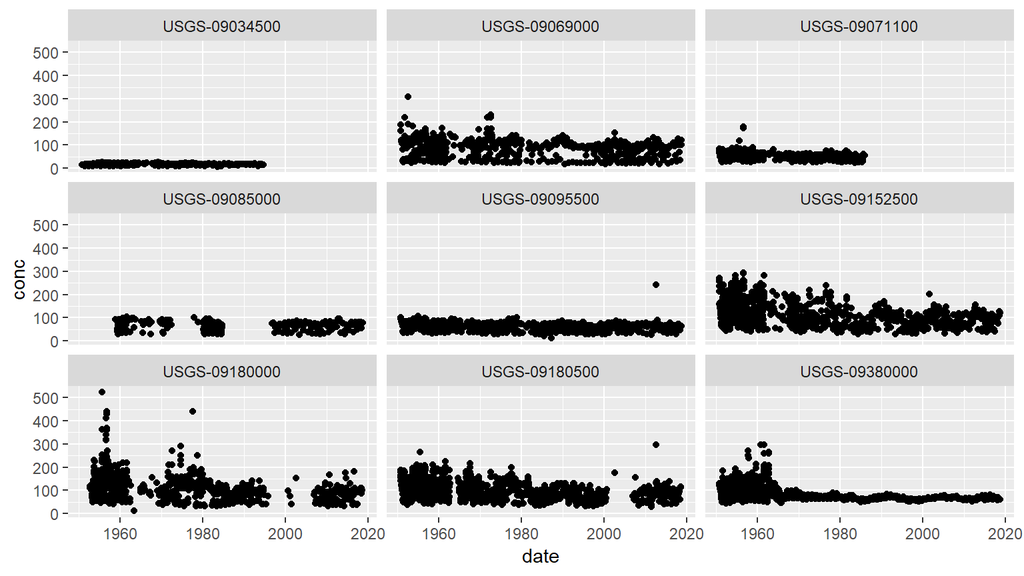

```r
conc.daily %>%
  filter(parameter == 'Calcium') %>%
  ggplot(.,aes(x=date,y=conc)) +
  geom_point() +
  facet_wrap(~SiteID)
```

## Annual summaries of full sites

- Let’s shrink the dataset to only look at annual change.
- Again we can use the powers of `group_by` and `summarize` to do this

```r
too.few.years <- c('USGS-09034500','USGS-0907110','USGS-0908500')

conc.annual <- conc.daily %>%
  filter(!SiteID %in% too.few.years) %>% #! means opposite of, so we want all the sites not in the too.few years vector.
  mutate(year=year(date)) %>%
  group_by(SiteID,year,parameter) %>%
  summarize(annual_mean=mean(conc,na.rm=T),
            annual_var=var(conc,na.rm=T))
```

## Plot of all the annual data.

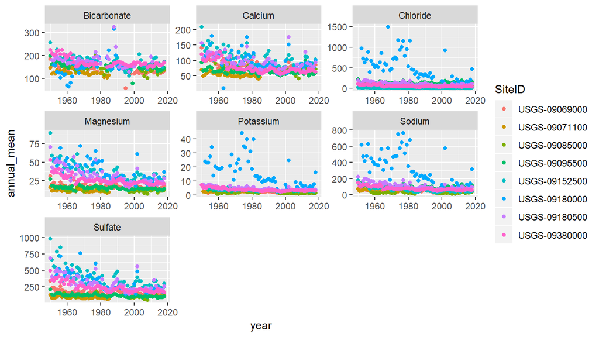

```r
conc.annual %>%
  ggplot(.,aes(x=year,y=annual_mean,color=SiteID)) +
  geom_point() +
  facet_wrap(~parameter,scales='free')
```

That plot is… ugly! Maybe we can make something prettier

## Prettier annual plot.

- Join the data to basin names so data is easier to interpret
- Use the command `left_join` do this
- Use the command `rename` to make sure joining columns have the same name

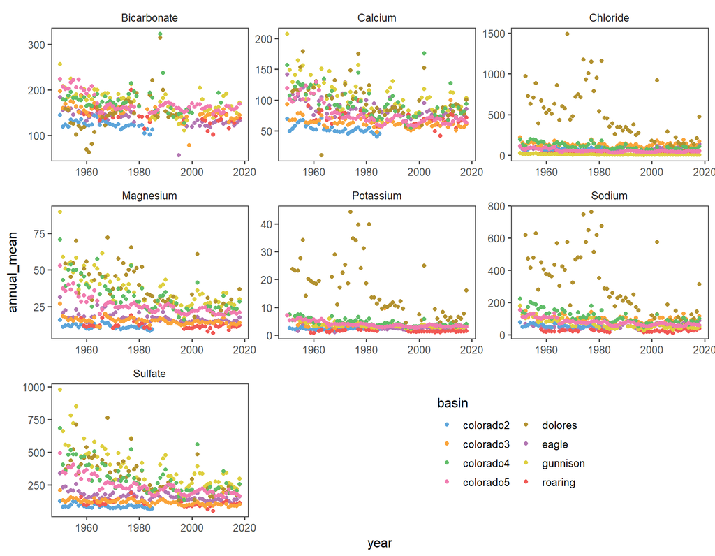

```r
conc.annual %>%
  left_join(colorado %>%
              rename(SiteID=sites),by='SiteID') %>%
  ggplot(.,aes(x=year,y=annual_mean,color=basin)) +
  geom_point() +
  facet_wrap(~parameter,scales='free') +
  theme_few() +
  scale_color_few() +
  theme(legend.position=c(.7,.15)) +
  guides(color=guide_legend(ncol=2))
```

## Watershed size

- Many prior publications have shown that increasing watershed size means decreasing variance in anion and cation concentrations.
- We can use our dataset to test this in the colorado basin.

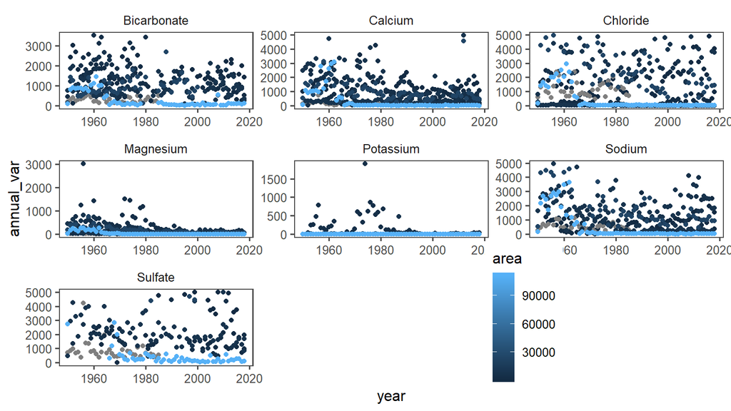

```r
conc.annual %>%
  left_join(site.info,by='SiteID') %>%
  filter(annual_var < 5000) %>%
  ggplot(.,aes(x=year,y=annual_var,color=area)) +
  geom_point() +
  facet_wrap(~parameter,scales='free') +
  theme_few() +
  theme(legend.position=c(.7,.15))
```

## Reshaping the data

- From basic weathering geochemistry principles we know that [Bicarbonate] ~ Mg + Ca
- The current shape of the data in a ‘long’ format makes looking at these correlations impossible.
- We need to ‘widen’ the data so the constituents are arranged in sideXside columns.
- This data rearranging is really easy with tidyr `spread` and `gather`

```r
conc.wide <- conc.annual %>%
  select(-annual_var) %>%
  spread(key=parameter,value=annual_mean) %>%
  mutate(`Mg+Ca`=Magnesium+Calcium)

head(conc.wide)
```

```
## # A tibble: 6 x 10
## # Groups:   SiteID, year [6]
##   SiteID  year Bicarbonate Calcium Chloride Magnesium Potassium Sodium
##   <chr>  <dbl>       <dbl>   <dbl>    <dbl>     <dbl>     <dbl>  <dbl>
## 1 USGS-~  1950        184.    142.    107.       31.6     NA      NA
## 2 USGS-~  1951        155.    102      76.8      20.7     NA      NA
## 3 USGS-~  1952        161.    109.     53.9      22.5     NA      66
## 4 USGS-~  1953        154.    100.     81.0      17.3     NA      57.4
## 5 USGS-~  1954        159.    106.     94.4      17.1      1.5    65.4
## 6 USGS-~  1955        145.    100.     79.2      17.8      2.74   53.4
## # ... with 2 more variables: Sulfate <dbl>, `Mg+Ca` <dbl>
```

## Plot of Bicarbonate vs Mg+Ca by site

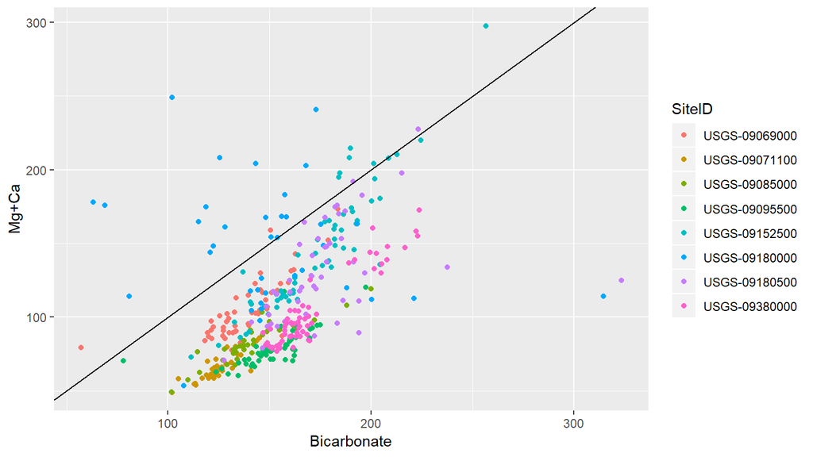

```r
ggplot(conc.wide,aes(x=Bicarbonate,y=`Mg+Ca`,color=SiteID)) +
  geom_point() +
  geom_abline(slope=1,intercept=0)
```

## Model changes

## Nesting and modelling

- `purrr` and `tidyr` make doing multiple models on different sites really easy.
- “Nesting” data wraps data into a nice tidy bundle for parallel analyses down the road
- These “nests” are *inside* of the tibble. Making it easy to look at them. Easier than lists anyhow!

```r
conc.nest <- conc.annual %>%
  group_by(parameter,SiteID) %>%
  nest()

head(conc.nest)
```

```
## # A tibble: 6 x 3
##   parameter   SiteID        data
##   <chr>       <chr>         <list>
## 1 Bicarbonate USGS-09069000 <tibble [52 x 3]>
## 2 Calcium     USGS-09069000 <tibble [69 x 3]>
## 3 Chloride    USGS-09069000 <tibble [69 x 3]>
## 4 Magnesium   USGS-09069000 <tibble [69 x 3]>
## 5 Sulfate     USGS-09069000 <tibble [69 x 3]>
## 6 Sodium      USGS-09069000 <tibble [66 x 3]>
```

## Modelling on nested data using `purrr`

- We can then build a simple model (concentration ~ year)
- This model can be applied to all sites using a `purrr::map` function

```r
#Create a generic model function (mean as afunction of time)
time.lm.models <- function(x){
  mod <- lm(annual_mean~year,data=x)
}

conc.models <- conc.nest %>%
  mutate(mods=map(data,time.lm.models))

head(conc.models)
```

```
## # A tibble: 6 x 4
##   parameter   SiteID        data              mods
##   <chr>       <chr>         <list>            <list>
## 1 Bicarbonate USGS-09069000 <tibble [52 x 3]> <S3: lm>
## 2 Calcium     USGS-09069000 <tibble [69 x 3]> <S3: lm>
## 3 Chloride    USGS-09069000 <tibble [69 x 3]> <S3: lm>
## 4 Magnesium   USGS-09069000 <tibble [69 x 3]> <S3: lm>
## 5 Sulfate     USGS-09069000 <tibble [69 x 3]> <S3: lm>
## 6 Sodium      USGS-09069000 <tibble [66 x 3]> <S3: lm>
```

## Using `broom` to look at model results

- We now have a series of nested model results
- But we want to look at those summary results
- `broom::glance` makes looking at these data clean and tidy

```r
conc.models %>%
  mutate(mod.glance=map(mods,glance)) %>%
  unnest(mod.glance) %>% #Unnesting unwraps the nested column.
  arrange(desc(adj.r.squared)) %>%
  select(parameter,SiteID,adj.r.squared,p.value,logLik,AIC) %>%
  kable(.,'html') %>%
  kable_styling() %>%
  scroll_box(width='600px',height='500px')
```

| parameter | SiteID | adj.r.squared | p.value | logLik | AIC |
| --- | --- | --- | --- | --- | --- |
| Sulfate | USGS-09380000 | 0.6772651 | 0.0000000 | -350.870859 | 707.74172 |
| Sodium | USGS-09380000 | 0.6459794 | 0.0000000 | -276.576629 | 559.15326 |
| Potassium | USGS-09380000 | 0.6360325 | 0.0000000 | -62.709079 | 131.41816 |
| Sodium | USGS-09152500 | 0.5897497 | 0.0000000 | -299.186578 | 604.37316 |
| Magnesium | USGS-09380000 | 0.5882953 | 0.0000000 | -191.059324 | 388.11865 |
| Chloride | USGS-09152500 | 0.5862174 | 0.0000000 | -171.165099 | 348.33020 |
| Sodium | USGS-09180500 | 0.5808220 | 0.0000000 | -298.222272 | 602.44454 |
| Potassium | USGS-09180500 | 0.5728682 | 0.0000000 | -73.182677 | 152.36535 |
| Calcium | USGS-09380000 | 0.5546482 | 0.0000000 | -270.578459 | 547.15692 |
| Sulfate | USGS-09152500 | 0.5235337 | 0.0000000 | -423.829743 | 853.65949 |
| Magnesium | USGS-09180500 | 0.5154145 | 0.0000000 | -219.624495 | 445.24899 |
| Magnesium | USGS-09152500 | 0.5075456 | 0.0000000 | -247.451305 | 500.90261 |
| Chloride | USGS-09380000 | 0.4934803 | 0.0000000 | -274.012922 | 554.02584 |
| Chloride | USGS-09180500 | 0.4828466 | 0.0000000 | -307.101623 | 620.20325 |
| Sulfate | USGS-09180000 | 0.4779850 | 0.0000000 | -359.463584 | 724.92717 |
| Potassium | USGS-09152500 | 0.4574209 | 0.0000000 | -76.152187 | 158.30437 |
| Magnesium | USGS-09180000 | 0.4543047 | 0.0000000 | -215.250536 | 436.50107 |
| Bicarbonate | USGS-09380000 | 0.4535112 | 0.0000000 | -265.056451 | 536.11290 |
| Sodium | USGS-09180000 | 0.4491046 | 0.0000000 | -381.740135 | 769.48027 |
| Sulfate | USGS-09180500 | 0.4320180 | 0.0000000 | -380.957924 | 767.91585 |
| Calcium | USGS-09071100 | 0.4208825 | 0.0000113 | -111.375068 | 228.75014 |
| Chloride | USGS-09180000 | 0.3905904 | 0.0000001 | -415.903140 | 837.80628 |
| Potassium | USGS-09180000 | 0.3885512 | 0.0000002 | -194.882165 | 395.76433 |
| Calcium | USGS-09152500 | 0.3885508 | 0.0000000 | -312.510616 | 631.02123 |
| Calcium | USGS-09069000 | 0.3721748 | 0.0000000 | -272.630433 | 551.26087 |
| Sulfate | USGS-09069000 | 0.3712905 | 0.0000000 | -335.791142 | 677.58228 |
| Bicarbonate | USGS-09071100 | 0.3675127 | 0.0000678 | -118.738603 | 243.47721 |
| Bicarbonate | USGS-09069000 | 0.3633262 | 0.0000014 | -213.428927 | 432.85785 |
| Sulfate | USGS-09095500 | 0.3414236 | 0.0000001 | -298.470021 | 602.94004 |
| Magnesium | USGS-09069000 | 0.3331641 | 0.0000001 | -167.048175 | 340.09635 |
| Bicarbonate | USGS-09095500 | 0.3257874 | 0.0000032 | -220.015183 | 446.03037 |
| Bicarbonate | USGS-09152500 | 0.3205921 | 0.0000018 | -263.610283 | 533.22057 |
| Sulfate | USGS-09071100 | 0.2896245 | 0.0004216 | -141.393380 | 288.78676 |
| Bicarbonate | USGS-09085000 | 0.2755928 | 0.0004238 | -158.415607 | 322.83121 |
| Magnesium | USGS-09071100 | 0.2751876 | 0.0006054 | -62.054512 | 130.10902 |
| Magnesium | USGS-09095500 | 0.2528478 | 0.0000064 | -149.679609 | 305.35922 |
| Bicarbonate | USGS-09180000 | 0.2444717 | 0.0006991 | -199.776225 | 405.55245 |
| Calcium | USGS-09180500 | 0.2210237 | 0.0000527 | -284.565276 | 575.13055 |
| Sodium | USGS-09071100 | 0.1994830 | 0.0036942 | -131.920999 | 269.84200 |
| Calcium | USGS-09085000 | 0.1883742 | 0.0021324 | -158.202509 | 322.40502 |
| Magnesium | USGS-09085000 | 0.1763933 | 0.0029500 | -97.021952 | 200.04390 |
| Calcium | USGS-09180000 | 0.1760308 | 0.0006148 | -270.600668 | 547.20134 |
| Chloride | USGS-09071100 | 0.1696970 | 0.0072757 | -145.595535 | 297.19107 |
| Calcium | USGS-09095500 | 0.1505639 | 0.0005802 | -239.599523 | 485.19905 |
| Sulfate | USGS-09085000 | 0.1502104 | 0.0054211 | -198.395231 | 402.79046 |
| Chloride | USGS-09069000 | 0.1302571 | 0.0013543 | -305.210533 | 616.42107 |
| Sodium | USGS-09095500 | 0.0914942 | 0.0082327 | -276.579755 | 559.15951 |
| Sodium | USGS-09069000 | 0.0717617 | 0.0168333 | -258.943298 | 523.88660 |
| Potassium | USGS-09095500 | 0.0676751 | 0.0222808 | -83.900221 | 173.80044 |
| Chloride | USGS-09085000 | 0.0473046 | 0.0838817 | -154.792299 | 315.58460 |
| Bicarbonate | USGS-09180500 | 0.0191830 | 0.1681193 | -238.455842 | 482.91168 |
| Potassium | USGS-09085000 | 0.0147261 | 0.2137116 | -5.011260 | 16.02252 |
| Chloride | USGS-09095500 | 0.0142301 | 0.1638435 | -323.211924 | 652.42385 |
| Sodium | USGS-09085000 | -0.0031049 | 0.3564164 | -138.149355 | 282.29871 |
| Potassium | USGS-09069000 | -0.0068800 | 0.4533067 | -30.715079 | 67.43016 |
| Potassium | USGS-09071100 | -0.0150024 | 0.4855686 | -4.343084 | 14.68617 |